**NOTE:** The following questions are all done by Shun himself only.

# Homework 1 (9-1-25)

## Exercises [1.1] 1, 2, 3, 4, 6

### Exercise 1.1.1

(a) As $d = 4$, $[1, 2)$ contains $2^d = 16$ elements in $\mathbb{F}$. Taking $e = -1$ and $1$ respectively, we know $[\frac{1}{2}, 1)$ and $[2, 4)$ both contain $16$ elements respectively in $\mathbb{F}$. Hence, in total, in $[\frac{1}{2}, 4]$, there are $16 + 16 + 16 + 1 = \boxed{49}$ elements of $\mathbb{F}$ including the endpoints.

(b) $[1, 2)$ is divided into $16$ partitions. Hence, take $e = -4$, $[\frac{1}{16}, \frac{1}{8})$ is divided into $16$ partitions. Notice, $\frac{1}{10} - \frac{1}{16} = \frac{9.6}{16(16)}$. As $|\frac{1}{10} - (\frac{1}{16} + \frac{1}{16} (\frac{10}{16}))| < |\frac{1}{10} - (\frac{1}{16} + \frac{1}{16} (\frac{9}{16}))|$, thus $\frac{1}{16} + \frac{1}{16}(\frac{10}{16}) = \boxed{0.1015625}$ is the element in $\mathbb{F}$ closest to $\frac{1}{10}$.

(c) Take $e = 4$, $[16, 32)$ contains $16$ elements in $\mathbb{F}$, i.e. each partition occurs at an integer. Similarly, $e < 4$ still contaains all integer elements in the ranges. However, take $e = 5$, $[32, 64)$ contains $16$ elements in $\mathbb{F}$. Hence, the partitions occur only at even integers. This means, the smallest positive number not in $\mathbb{F}$ is $\boxed{33}$.

### Exercise 1.1.2

Recall, $(1.1.3)$ states $\frac{|f\ell(x) - x|}{|x|} \leq \frac{1}{2} \varepsilon_{mach}$, and (1.1.4) states $f\ell(x) = x(1 + \varepsilon)$ for some $|\varepsilon| \leq \frac{1}{2} \varepsilon_{mach}$.

Notice, $\frac{|f\ell(x) - x|}{|x|} \leq \frac{1}{2} \varepsilon_{mach} \Leftrightarrow x - \frac{1}{2}|x|\varepsilon_{mach} \leq f\ell(x) \leq x + \frac{1}{2}|x|\varepsilon_{mach}$. This happens iff when $x \geq 0$ we have $x (1 - \frac{1}{2}\varepsilon_{mach}) \leq f\ell(x) \leq x (1 + \frac{1}{2}\varepsilon_{mach})$, and when $x \leq 0$ we have $x (1 + \frac{1}{2}\varepsilon_{mach}) \leq f\ell(x) \leq x (1 - \frac{1}{2}\varepsilon_{mach})$. This is equivalent to saying $f\ell(x) = x(1 + \varepsilon)$ for some $\varepsilon \in [-\frac{1}{2}\varepsilon_{mach}, \frac{1}{2}\varepsilon_{mach}]$, i.e. $|\varepsilon| \leq \frac{1}{2}\varepsilon_{mach}$.

Hence, (1.1.3) is equivalent to (1.1.4).

### Exercise 1.1.3

```python
# This is the code for exercise 1.1.3
import math

# Evaluate constants
A = 355/113
B = 103638/32989

# Absolute accuracy
A_ac = abs(math.pi - A)
B_ac = abs(math.pi - B)

print(f"Absolute accuracies: (a) {A_ac} (b) {B_ac}")

# Relative accuracy
A_rc = A_ac / A
B_rc = B_ac / B

print(f"Relative accuracies: (a) {A_rc} (b) {B_rc}")
```

```
Absolute accuracies: (a) 2.667641894049666e-07 (b) 1.493639878447084e-09
Relative accuracies: (a) 8.491367155707388e-08 (b) 4.754403399341058e-10
```

### Exercise 1.1.4

(a) In the interval $[1, 2)$, there will now be $2^{23}$ partitions. Hence, the first precision number greater than $1$ here is $\boxed{1 + 2^{-23} \approx 1.0000001192092896}$.

(b) Take $e = 23$, then $[2^{23}, 2^{24})$ creates $2^{23}$ partitions. As the intervals with values less than $2^{23}$ would have smaller partitions, this means all positive integers less than $2^{24}$ are single precision numbers. Now, take $e = 24$, $[2^{24}, 2^{25})$ still has the same number of partitions, but only even integers in this range are single precision numbers. This means, the smallest positive integer that is not a single precision number is $\boxed{2^{24} + 1}$.

### Exercise 1.1.6

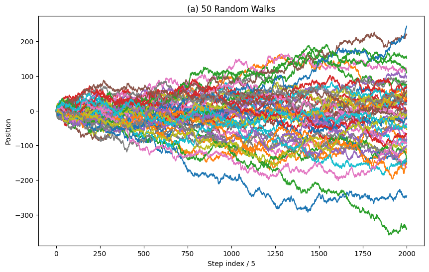

```python
# This is the code for exercise 1.1.6(a)
import numpy as np
import matplotlib.pyplot as plt

# Parameters
n = 10000
num_walks = 50

# Random walk
plt.figure(figsize=(10,6))
for _ in range (num_walks):
    r = np.random.randn(n)
    x = np.cumsum(np.sign(r))
    plt.plot(x[::5]) # Every fifth number

plt.title("(a) 50 Random Walks")
plt.xlabel("Step index / 5")
plt.ylabel("Position")
plt.show()
```

```python
# This is the code for exercise 1.1.6(b)
import math
import numpy as np

# Parameters
n = 10000
num_walks = 1000000 # Million random walks
bucket = 10000

buckets = num_walks // bucket
avg = 0
abs_avg = 0

# Random walk
for _ in range (buckets): # Loop over buckets
    # Generate at once
    steps = np.sign(np.random.randn(bucket, n))

    # Final displacement of each walk
    finals = steps.sum(axis=1)

    avg += finals.mean()
    abs_avg += np.abs(finals).mean()


# Compre values
avg /= buckets
abs_avg /= buckets
print(f"When n = {n}, we get:\nAverage values of x_10000 = {avg}, compared to alpha_n approx 0\nAverage values of |x_10000| ≈ {abs_avg}, compared to beta_n ≈ {math.sqrt(2 * n / math.pi)}")
```

```
When n = 10000, we get:
Average values of x_10000 = -0.1461, compared to alpha_n approx 0
Average values of |x_10000| ≈ 79.813436, compared to beta_n ≈ 79.78845608028654
```